# Survival analysis for the Stanford Heart Transplant Data

Oleg Kufirin

19/03/2021

# Dataset

[Link to the interactive Shiny app](https://oleg-kufirin.shinyapps.io/HTx_Survival_Analysis/)

Time-dependent variables can be used to model the effects of subjects transferring from one treatment group to another. One example of the need for such strategies is the Stanford heart transplant program. Patients are accepted if physicians judge them suitable for heart transplant. Then, when a donor becomes available, physicians choose transplant recipients according to various medical criteria. A patient’s status can be changed during the study from waiting for a transplant to transplant recipient.

Crowley and Hu (J. Amer. Statist. Assoc., 1977) describe a program at Stanford University where 103 patients were registered to recieve a heart transplant and were followed until death or censorship. Of these, 65 received transplants during follow-up, whereas 38 did not.

Here is the head of the dataset imported from *p3state.msm* package:

```
  times1 delta times2 time status        age      year surgery
1     50     0      0   50      1 -17.155373 0.1232033       0
2      6     0      0    6      1   3.835729 0.2546201       0
3      1     1     15   16      1   6.297057 0.2655715       0
4     36     1      3   39      1  -7.737166 0.4900753       0
5     18     0      0   18      1 -27.214237 0.6078029       0
6      3     0      0    3      1   6.595483 0.7008898       0
```

[Reference to the dataset description](https://rdrr.io/cran/p3state.msm/man/heart2.html)

# Study question

In this project we would like to assess the impact of the following characteristics of patients from the heart transplant waiting list on their survival.

- Transplant event. Do patients with transplanted hearts live longer?
- Age group. Do certain age groups have better or worse prognosis?
- Year group. Is there any difference in survival of patients from different groups of time of acceptance into the program after 1 Nov 1967?
- Surgery. Does having a prior bypass surgery lead to better or worse prognosis?

To do this we will apply Kaplan-Meier estimate and Cox Proportional Hazard Model. The app allows manipulation of model parameters and visualises survival curves.

#### Data preparation

Variables *times1* and *times2* were ignored for the analysis. Variable *delta* was renamed to *Transplant*. Variable *age* was brought to the original scale and categorised to *Age Group*. Variable *year* was also categorised to *Year Group*.

# Kaplan-Meier Survival Estimate

On the first tab of the app a user can see the Kaplan-Meier Survival Curve and the Cumulative Hazard Curve for chosen variable of interest. All variables are categorical and described in the data dictionary at the bottom of the left panel. A user can choose factor of interest from Stratification Factor drop-down list.

Below is an example of a KM curve for Age Group variable. As it can be seen younger patients below 40 have better survival outcome given they are accepted in the waiting list. This is not a surprising result but it shows how other variables can be explored in a similar fashion.

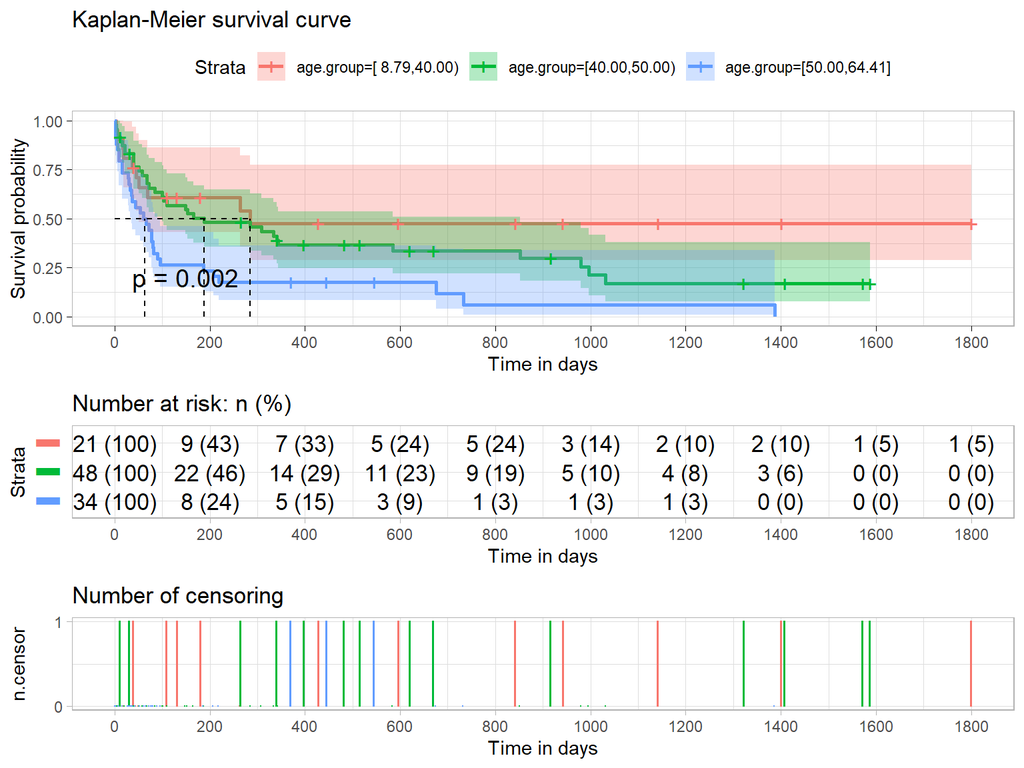

[Reference about Kaplan-Meier Survival Estimate](http://www.sthda.com/english/wiki/survival-analysis-basics)

# Cox Proportional-Hazards Model

On the second tab a user can see a survival curve built with Cox Proportional-Hazards Model, model summary and the predicted curve based on the user’s input. Regressors that a user wants to include in the model can be selected with the tick-boxes on the left panel. Model summary is given below the curve and contains useful information such as coefficient values and results of statistical tests. Survival curve for a new patient will be drawn at the bottom where input values are specified on the left panel under ‘Prediction’ section. Only regressors included in the model will have an effect on prediction despite other existing input values.

Below is an example of a Cox PH curve of a univariate model for Transplant variable.

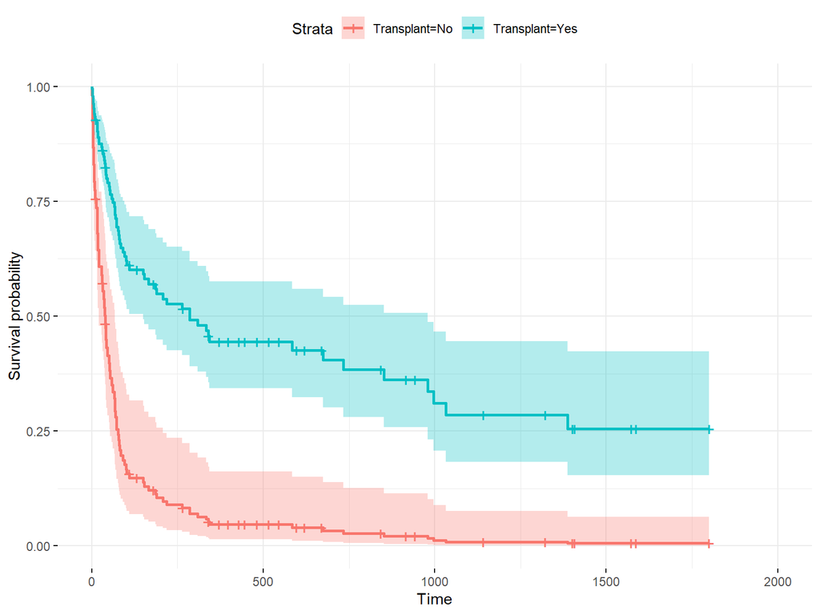

[Reference about Cox Proportional-Hazards Model](http://www.sthda.com/english/wiki/cox-proportional-hazards-model)